# Kristina Mensik - PS 9

## Problem 1

### 1a.

$$rate_i = \beta_0 + \beta_1acpt_i + \beta_2slim_i + \beta_3sigs1_i +
\beta_4shld_i + u_i$$

### 1b.

**acpt**: 0.09081; change in the rate of accidents per million miles for one additional access point per mile, holding other road features constant

- *interpretation*:
  - an additional access point per mile is associated with a 0.09 increase in accidents/million miles, and this effect is statistically significant at the 1% level (bc p value is less than 0.01), where the confidence interval is [0.028, 0.154].

**slim**: -0.10408; change in the rate of accidents per million miles for unit (+5mph) increase in the speeding limit

- *Interpretation*: An additional unit (1 mile per hour) increase in the speed limit is associated with a 0.10408 fewer accidents per million miles. This effect is not statistically significant at the 95% confidence level, because although the probability of getting a t-statistic as “extreme” as |1.765| if the coefficient were 0 is fairly low (there’s an 8.7% chance we’d see a t-stat as extreme as 1.765), the confidence interval is [-0.2239, 0.015] – crosses 0, and the t value is less than acpt’s.

**sigs1**: 0.77379; change in the rate of accidents per million miles for unit increase in traffic light per mile

- An additional traffic light per mile is associated with 0.77 more accidents per million miles. This effect is statistically significant at the 95% confidence level ([0.05, 1.49] confidence interval, probability of getting a t-stat as extreme as 2.175 if beta were 0 is 3.6%).

**shld**: 0.02452; change in the rate of accidents per million miles for unit increase in shoulder road width

- An additional foot in shoulder width is associated with 0.02452 accidents per million miles. This effect is not statistically significant – 95% CI [-0.16, 0.211] includes 0.

### 1c.

**acpt:** The positive effect of access points on accident rates is still significant using a 1-tailed test. We can reject the null that additional access points do not increase accidents.

- Interested in positive direction (beta greater than 0), null is that it’s negative
- Half of p value 0.005 is still positive, so valid
- half the p value is also still less than 0.05, so I reject the null
- but on a 90% [0.39, 0.14] interval

**slim:** Where the negative effect of a mile-per-hour increase in the speed limit on accidents per million miles was *not* significant with a two-tailed test, it *is* significant with a 1-tailed test, allowing us to reject the null (that an additional MPH speed limit does not have an effect on accidents).

- intersted in negative direction (beta less than 0), null is that it’s positive, and slim coeff is negative
- half the p value is 0.04329, which is positive, so valid
- half the p value is also less than 0.05 (tho cutting it a bit close), so we can reject the null
- now 90% confidence interval [-0.2038, -0.0043], doesn’t cross 0

**sigs1:** the positive effect of traffic lights on traffic accidents is significant with a 1-tailed test CI [0.17, 1.37], so we can reject the null that an additional traffic light per mile does not increase accidents.

**shld:** the effect of an additional foot of shoulder width is still not statistically significant at the 1-tailed test.

### 1d.

First, it may be worth noting that an n of 39 and k of 4 makes for a fairly small degrees of freedom (34), the significance tests rely on the normality of residuals assumption more than asymptotic properties of large samples.

The intercept tells us that when there are no vehicle access points, a 0 mph speed limit, 0 turn signals, and no road shoulders, the rate of accidents per million miles is about 8. In other words, perhaps, an unmarked, unofficial country road is still predicted to have 8 accidents per 1 million miles – whether such a million mile road exists seems dubious, so taken literally this doesn’t seem meaningful, and also this predictor and the others set to 0 is outside of the support of the data (ie, mph starts at 40 in this data).

**acpt:** One additional access point per mile is associated with 0.09 more accidents per million miles, and this effect is statistically significant at the 1% level with both a 1 and 2 tailed test.

**slim:** Speed limit has a negative effect on accidents per million miles, but it’s only significant with a one-tailed test (at the 5% level for a two-tailed p=0.087).

**sigs1:** An additional traffic light per mile is associated with 0.77 additional accidents per million miles, and this effect is significant. The effect of an additional foot in shoulder width, **shld** is a 0.02 more accidents per million miles, but this isn’t statistically significant.

*Scale* in this case is confusing, though, in part because a change per million miles of road in a context where the longest highway I know of in the US is ~3k miles is out of my intuitive purview.

Trying to get more concrete with acpt for example, I say then that a 10-access point increase per mile of road leads to almost 1 more accident per million miles, but that becomes meaningless given the distribution of access points per mile in the dataset (acpt the range is 2.2 to 53 access points per mile of road, but clustered between ~7 and ~15 access points per mile, making that substantively a-typical. Maybe the best way to “scale” it is to use the IQR, or say that moving from the 25th percentile to the 75th percentile in access points per mile is associated with roughly 0.7 more accidents per mile, which is associated with about a 9% increase relative to the average accident rate (but that’s using an intercept that isn’t super meaningful).

### 1e.

The model explains a good deal of variation in accident rates across roads (63-67%) and the ~4 point drop suggests that at least one of th predictors in the model is explaining less than it’s change in k (is useless). That is probably shld.

### 1f.

```
## [1] 0.02892793 0.15269871
```

```
## [1] -0.22393093  0.01577477
```

```
## [1] 0.05092461 1.49665627
```

```
## [1] -0.1621756  0.2112175
```

The following confidence intervals relate to the coefficients’ p values in that both are constructed from the same sampling distribution, which so far we’re applying GM assumptions/asymptotics to assume is normally distributed around the true values of beta; and from the same standard error (square root of the diagonal of the vcov matrix).

The two-sided (in this case) 95% confidence intervals are basically the set of plausible values/null hypotheses that wouldn’t be rejected at a 5 percent significance. If 0 is outside of the confidence intervals, the two-tailed p values will be less than 0.05; if inside, the p values will be more than 0.5. Perhaps the strong point is that the spherical errors assumption is wrong, then standard errors are wrong and confidence intervals are also wrong (tho separate ways to ask the same question, their answers are constructed based off the same value/assumption).

Acpt’s CI [0.0289, 0.1526]

slim [-0.2239, 0.01577]

sigs1: [0.0509, 1.4966]

shld: [-0.1621, 0.2112]

### 1g.

```
##             coefficient se.robust  t.value p.value
## (Intercept)     7.98973   3.91990  2.03825 0.04936
## acpt            0.09081   0.06413  1.41619 0.16582
## slim           -0.10408   0.06284 -1.65624 0.10687
## sigs1           0.77379   0.46565  1.66174 0.10576
## shld            0.02452   0.08763  0.27983 0.78130
```

Het-Robust SEs Table

|  | coefficient | se.robust | t.value | p.value |
| --- | --- | --- | --- | --- |
| (Intercept) | 7.9897349 | 3.9198988 | 2.0382503 | 0.0493638 |
| acpt | 0.0908133 | 0.0641253 | 1.4161851 | 0.1658181 |
| slim | -0.1040781 | 0.0628398 | -1.6562443 | 0.1068742 |
| sigs1 | 0.7737904 | 0.4656501 | 1.6617423 | 0.1057590 |
| shld | 0.0245209 | 0.0876285 | 0.2798283 | 0.7813047 |

## Problem 2

Use the dataset `chile.csv`. These are data on citizen characteristics and voting intentions in the 1988 Chilean plebiscite. The variables of interest are as follows:

- *vote_yes*: 1=will vote yes for Pinochet, 0=will vote no against Pinochet
- *statusquo*: higher values = more support for the status quo, standardized to have mean zero and standard deviation of one
- *income*: monthly income, in pesos
- *education*: factor variable with 3 levels: primary only (baseline), post-secondary (PS), secondary (S)
- *sex*: factor variable with two levels, female (baseline) and male (M)
1. Created a new variable called `income_1000` which transforms `income` so that it is measured in thousands of pesos. Estimated model (`m2`):

$$voteyes_i = \beta_0 + \beta_1sexM_i + \beta_2educationPS_i +
\beta_3educationS_i + \\ \beta_4income1000_i + \beta_5statusquo_i + \\
\beta_6(statusquo_i)(educationPS_i) + \beta_7(statusquo_i)(educationS_i)
+ u_i$$

```
##
## Call:
## lm(formula = vote_yes ~ sexM + educPS + educS + income_1000 +
##     statusquo + statusquo * educPS + statusquo * educS, data = chile)
##
## Residuals:
##      Min       1Q   Median       3Q      Max
## -1.07956 -0.10432 -0.03227  0.06820  1.05596
##
## Coefficients:
##                    Estimate Std. Error t value Pr(>|t|)
## (Intercept)       0.5582422  0.0121325  46.012  < 2e-16 ***
## sexM             -0.0445936  0.0125921  -3.541 0.000409 ***
## educPS           -0.0749597  0.0198659  -3.773 0.000167 ***
## educS            -0.0474466  0.0145303  -3.265 0.001115 **
## income_1000      -0.0001294  0.0001665  -0.777 0.437216
## statusquo         0.3652706  0.0090623  40.307  < 2e-16 ***
## educPS:statusquo  0.0421426  0.0159849   2.636 0.008456 **
## educS:statusquo   0.0350658  0.0130366   2.690 0.007220 **
## ---
## Signif. codes:  0 '***' 0.001 '**' 0.01 '*' 0.05 '.' 0.1 ' ' 1
##
## Residual standard error: 0.2573 on 1695 degrees of freedom
##   (728 observations deleted due to missingness)
## Multiple R-squared:  0.7364, Adjusted R-squared:  0.7353
## F-statistic: 676.5 on 7 and 1695 DF,  p-value: < 2.2e-16
```

### 2b.

Interpret the intercept: what is the substantive interpretation? Is it meaningful in this case? Why or why not? Remember what we said above about how to think about the expected value of the dependent variable when it is binary!

The intercept is probably meaningful in this case, if I assume that it’s possible for a women with only primary education to have a $0 monthly income (more likely if income is personal rather than household income). If so, it means the probability of voting for Pinochet is 0.5582 when that person’s support for the status quo is at its mean (var was standardized). If my assumption holds, this is a ‘real’ hypothetical person both in terms of the world being modeled and the context of the data.

### 2c.

$\beta_1$ is -0.04459, which means that males are 4.4 percentage points less likely to vote for Pinochet than females, holding all else fixed.

$\beta_2$ (educ PS) is -0.0749, which means that people are 7.4 percentage points less likely to vote yes for Pinochet when they have a post-secondary instead of a primary education, when support for the status quo is held at its mean and all else is held constant.

$\beta_3$ means that people with a secondary as opposed to a primary education are 4.7 percentage points less likely to vote yes for Pinochet, when support for the status quo is held at its mean, and holding all else constant.

### 2d.

$\beta_5$ (statusquo) is 0.3652, which means that people are 36 percentage points more likely to vote yes for Pinochet for a unit increase in support for the status quo, for those with only a primary education, and all else is held constant.

### 2e.

$\beta_6$ tells us that the effect of a unit increase in support for the status quo (on probability of voting yes for Pinochet) is 4.2 percentage points more for those with post-secondary as opposed to primary degrees. IOW: as support for the status quo increases, people with post-secondary degrees’ probability of voting yes for Pinochet increases a little faster than that of those with primary education.

$\beta_7$ tells us that the effect of a unit increase in support for the status quo (on probability of voting yes for Pinochet) is 3.5 percentage points more for those with secondary as opposed to primary degrees.

### 2f.

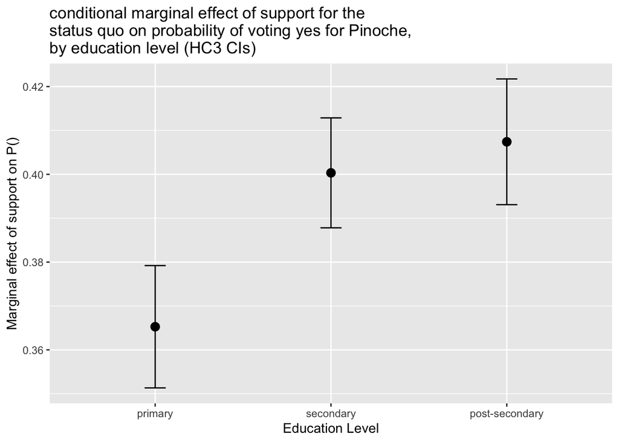